# Medical Student Attitudes Toward Personalized Medicine Report

### 0.9.1 Regression model for genomics section

We want to build a model using questions 26-30.2 to predict score on the genetics/genomics section of the survey.

```
##
##   0   1   2
##  45 108   8
```

```
##
##  0  1  2
## 45 87 29
```

```
##
##   0   1
##  98 112
```

```
##
## Call:
## lm(formula = genomics ~ Q26 + Q27.f + Q28.2 + Q29.1.f + Q30.1.f +
##     Q30c, data = infile3)
##
## Residuals:
##      Min       1Q   Median       3Q      Max
## -14.2932  -4.8592  -0.0529   4.4000  20.2909
##
## Coefficients:
##             Estimate Std. Error t value Pr(>|t|)
## (Intercept)  10.6765     3.9155   2.727 0.007203 **
## Q26          -0.9380     0.7839  -1.197 0.233482
## Q27.f1       -3.5326     1.0844  -3.258 0.001405 **
## Q28.2         2.6201     0.6717   3.901 0.000147 ***
## Q29.1.f1      1.9875     1.4003   1.419 0.158006
## Q30.1.f1      5.7449     3.9048   1.471 0.143437
## Q30.1.f2      7.3505     3.9651   1.854 0.065847 .
## Q30c1         2.1943     1.3471   1.629 0.105564
## Q30c2         4.8000     1.6534   2.903 0.004284 **
## ---
## Signif. codes:  0 '***' 0.001 '**' 0.01 '*' 0.05 '.' 0.1 ' ' 1
##
## Residual standard error: 6.427 on 142 degrees of freedom
##   (61 observations deleted due to missingness)
## Multiple R-squared:  0.2684, Adjusted R-squared:  0.2272
## F-statistic: 6.512 on 8 and 142 DF,  p-value: 3.244e-07
```

```
##
## Call:
## lm(formula = genomics ~ Q27.f + Q28.2 + Q29.1.f + Q30.1.f + Q30c,
##     data = infile3)
##
## Residuals:
##      Min       1Q   Median       3Q      Max
## -13.6808  -4.4274  -0.2683   4.7745  20.8808
##
## Coefficients:
##             Estimate Std. Error t value Pr(>|t|)
## (Intercept)   9.4677     3.7886   2.499 0.013587 *
## Q27.f1       -3.4613     1.0844  -3.192 0.001738 **
## Q28.2         2.1905     0.5686   3.853 0.000176 ***
## Q29.1.f1      1.8830     1.3997   1.345 0.180667
## Q30.1.f1      5.8869     3.9089   1.506 0.134264
## Q30.1.f2      7.4610     3.9700   1.879 0.062235 .
## Q30c1         2.3421     1.3435   1.743 0.083427 .
## Q30c2         5.0253     1.6451   3.055 0.002687 **
## ---
## Signif. codes:  0 '***' 0.001 '**' 0.01 '*' 0.05 '.' 0.1 ' ' 1
##
## Residual standard error: 6.437 on 143 degrees of freedom
##   (61 observations deleted due to missingness)
## Multiple R-squared:  0.261,  Adjusted R-squared:  0.2249
## F-statistic: 7.216 on 7 and 143 DF,  p-value: 2.144e-07
```

```
##
## Call:
## lm(formula = genomics ~ Q27.f + Q28.2 + Q29.1.f + Q30.1.f, data = infile3)
##
## Residuals:
##      Min       1Q   Median       3Q      Max
## -14.2913  -5.3703   0.0051   4.0359  21.3830
##
## Coefficients:
##             Estimate Std. Error t value Pr(>|t|)
## (Intercept)  16.3807     1.7074   9.594  < 2e-16 ***
## Q27.f1       -2.4521     0.9493  -2.583   0.0105 *
## Q28.2         2.8866     0.4982   5.794  2.7e-08 ***
## Q29.1.f1      2.0608     1.3831   1.490   0.1378
## Q30.1.f1     -0.6359     1.3620  -0.467   0.6411
## Q30.1.f2     -0.6503     1.4431  -0.451   0.6528
## ---
## Signif. codes:  0 '***' 0.001 '**' 0.01 '*' 0.05 '.' 0.1 ' ' 1
##
## Residual standard error: 6.704 on 196 degrees of freedom
##   (10 observations deleted due to missingness)
## Multiple R-squared:  0.194,  Adjusted R-squared:  0.1734
## F-statistic: 9.432 on 5 and 196 DF,  p-value: 4.502e-08
```

```
##
## Call:
## lm(formula = genomics ~ Q27.f + Q28.2 + Q29.1.f + Q30c, data = infile3)
##
## Residuals:
##      Min       1Q   Median       3Q      Max
## -14.5068  -4.4682   0.0061   4.5965  22.0581
##
## Coefficients:
##             Estimate Std. Error t value Pr(>|t|)
## (Intercept)  15.5010     1.5404  10.063  < 2e-16 ***
## Q27.f1       -2.9480     1.0894  -2.706  0.00761 **
## Q28.2         2.4409     0.5674   4.302 3.07e-05 ***
## Q29.1.f1      1.9464     1.3759   1.415  0.15929
## Q30c1         1.5279     1.2976   1.177  0.24091
## Q30c2         4.1902     1.6418   2.552  0.01173 *
## ---
## Signif. codes:  0 '***' 0.001 '**' 0.01 '*' 0.05 '.' 0.1 ' ' 1
##
## Residual standard error: 6.608 on 147 degrees of freedom
##   (59 observations deleted due to missingness)
## Multiple R-squared:  0.2255, Adjusted R-squared:  0.1992
## F-statistic: 8.561 on 5 and 147 DF,  p-value: 3.876e-07
```

```
##
## Call:
## lm(formula = genomics ~ Q27.f + Q28.2 + Q29.1 + Q30.1.f, data = infile3)
##
## Residuals:
##      Min       1Q   Median       3Q      Max
## -14.2913  -5.3703   0.0051   4.0359  21.3830
##
## Coefficients:
##             Estimate Std. Error t value Pr(>|t|)
## (Intercept)  16.3807     1.7074   9.594  < 2e-16 ***
## Q27.f1       -2.4521     0.9493  -2.583   0.0105 *
## Q28.2         2.8866     0.4982   5.794  2.7e-08 ***
## Q29.1         2.0608     1.3831   1.490   0.1378
## Q30.1.f1     -0.6359     1.3620  -0.467   0.6411
## Q30.1.f2     -0.6503     1.4431  -0.451   0.6528
## ---
## Signif. codes:  0 '***' 0.001 '**' 0.01 '*' 0.05 '.' 0.1 ' ' 1
##
## Residual standard error: 6.704 on 196 degrees of freedom
##   (10 observations deleted due to missingness)
## Multiple R-squared:  0.194,  Adjusted R-squared:  0.1734
## F-statistic: 9.432 on 5 and 196 DF,  p-value: 4.502e-08
```

```
##
## Call:
## lm(formula = genomics ~ Q27.f + Q28.2 + Q30c, data = infile3)
##
## Residuals:
##      Min       1Q   Median       3Q      Max
## -15.3652  -4.6587  -0.1981   4.3268  21.9507
##
## Coefficients:
##             Estimate Std. Error t value Pr(>|t|)
## (Intercept)  15.5143     1.5250  10.173  < 2e-16 ***
## Q27.f1       -2.9711     1.0828  -2.744  0.00681 **
## Q28.2         2.5350     0.5632   4.501 1.35e-05 ***
## Q30c1         1.6137     1.2781   1.263  0.20870
## Q30c2         4.6819     1.6091   2.910  0.00417 **
## ---
## Signif. codes:  0 '***' 0.001 '**' 0.01 '*' 0.05 '.' 0.1 ' ' 1
##
## Residual standard error: 6.613 on 150 degrees of freedom
##   (57 observations deleted due to missingness)
## Multiple R-squared:  0.2258, Adjusted R-squared:  0.2051
## F-statistic: 10.94 on 4 and 150 DF,  p-value: 8.283e-08
```

```
##
## Call:
## lm(formula = genomics ~ Q26 + Q27 + Q28.2 + Q29.1.f + Q30.1c +
##     Q30c, data = infile3)
##
## Residuals:
##      Min       1Q   Median       3Q      Max
## -14.6318  -4.6767   0.0283   4.3586  21.1256
##
## Coefficients:
##             Estimate Std. Error t value Pr(>|t|)
## (Intercept)  17.0303     1.9091   8.921 2.01e-15 ***
## Q26          -0.9718     0.7903  -1.230  0.22085
## Q27          -3.2115     1.0795  -2.975  0.00344 **
## Q28.2         2.8159     0.6689   4.210 4.50e-05 ***
## Q29.1.f1      2.0892     1.4111   1.480  0.14095
## Q30.1c1      -1.1387     1.2180  -0.935  0.35140
## Q30c1         2.2457     1.3583   1.653  0.10046
## Q30c2         4.6316     1.6649   2.782  0.00613 **
## ---
## Signif. codes:  0 '***' 0.001 '**' 0.01 '*' 0.05 '.' 0.1 ' ' 1
##
## Residual standard error: 6.481 on 143 degrees of freedom
##   (61 observations deleted due to missingness)
## Multiple R-squared:  0.2507, Adjusted R-squared:  0.214
## F-statistic: 6.835 on 7 and 143 DF,  p-value: 5.259e-07
```

```
##
## Call:
## lm(formula = genomics ~ Q27 + Q28.2 + Q29.1.f + Q30.1c + Q30c,
##     data = infile3)
##
## Residuals:
##      Min       1Q   Median       3Q      Max
## -14.0022  -4.3495  -0.2372   4.5972  21.7501
##
## Coefficients:
##             Estimate Std. Error t value Pr(>|t|)
## (Intercept)   15.876      1.665   9.533  < 2e-16 ***
## Q27           -3.133      1.079  -2.902  0.00429 **
## Q28.2          2.374      0.565   4.201 4.64e-05 ***
## Q29.1.f1       1.982      1.411   1.405  0.16217
## Q30.1c1       -1.099      1.220  -0.901  0.36914
## Q30c1          2.400      1.355   1.771  0.07865 .
## Q30c2          4.862      1.657   2.934  0.00389 **
## ---
## Signif. codes:  0 '***' 0.001 '**' 0.01 '*' 0.05 '.' 0.1 ' ' 1
##
## Residual standard error: 6.493 on 144 degrees of freedom
##   (61 observations deleted due to missingness)
## Multiple R-squared:  0.2428, Adjusted R-squared:  0.2112
## F-statistic: 7.695 on 6 and 144 DF,  p-value: 3.489e-07
```

## 0.10 Concatenated Question 9 Analysis

We first wanted to do a collapsed t-test testing for an association between the openness/divergence components of EBPAS with question 9.

### 0.10.1 Collapsed t-test for EBPAS ~ Question 9

```
##
##  Welch Two Sample t-test
##
## data:  infile3$EBPAS by infile3$Q9c
## t = -4.5022, df = 65.194, p-value = 2.846e-05
## alternative hypothesis: true difference in means is not equal to 0
## 95 percent confidence interval:
##  -3.774156 -1.454791
## sample estimates:
## mean in group 1 mean in group 2
##        22.72093        25.33540
```

| Q9 Response Bin | N Responses | EBPAS Mean | EBPAS SD |
| --- | --- | --- | --- |
| 1 | 43 | 22.72093 | 3.396956 |
| 2 | 167 | NA | NA |
| NA | 2 | NA | NA |

On this question, those who answered question 9 as “Not at all/To a slight extent/To a moderate extent” has significantly lower scores than those who answered question 9 as “To a great extent/To a very great extent”.

### 0.10.2 Figure of Question 9 response frequences by Q28.2c groupings

We want to examine how people answer Question 9 by their medical school year grouping (pre-clinical, pre-didactic, clinical).

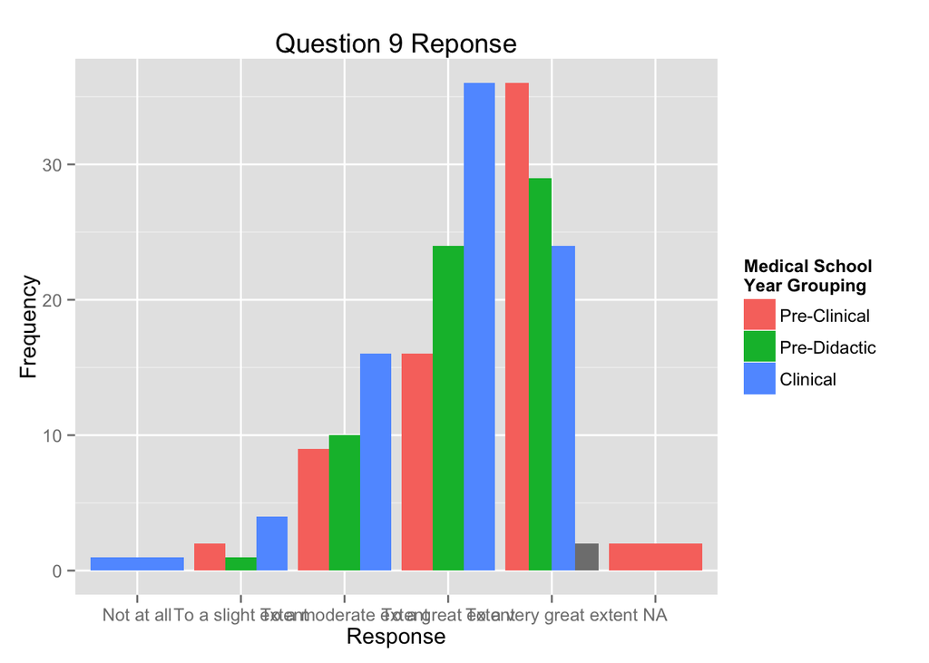

```r
##### Question 9 response, non-collapsed
infile3$Q9f <- factor(infile3$Q9)
levels(infile3$Q9f) <- c('Not at all','To a slight extent','To a moderate extent','To a great extent','To a very great extent')

g1 <- ggplot(data=infile3, aes(factor(Q9f), fill=factor(Q28.2c)))
g1 <- g1 + geom_bar(position="dodge", binwidth=0.25)
g1 <- g1 + ggtitle("Question 9 Reponse") + xlab("Response") + ylab('Frequency')
g1 <- g1 + scale_fill_discrete(name='Medical School\nYear Grouping', labels=c('Pre-Clinical','Pre-Didactic','Clinical'))
g1;
```

```r
# ##### Question 9 response, collapsed
# infile3$Q9cf <- factor(infile3$Q9c)
# levels(infile3$Q9cf) <- c('Not at all/\nTo a slight extent/\nTo a moderate extent','To a great extent/\nTo a very great extent')
#
# g1 <- ggplot(data=infile3, aes(factor(Q9cf), fill=factor(Q28.2c)))
# g1 <- g1 + geom_bar(position="dodge", binwidth=0.25)
# g1 <- g1 + ggtitle("Question 9 Reponse") + xlab("Response") + ylab('Frequency')
# g1 <- g1 + scale_fill_discrete(name='Medical School\nYear Grouping', labels=c('Pre-Clinical','Pre-Didactic','Clinical'))
# g1;
```